# MSAD-PCA Walkthrough

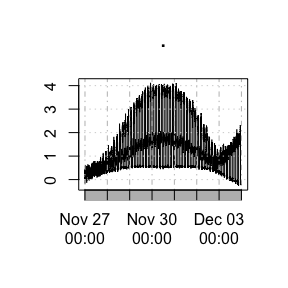

```r
faults_ls$fault2A$x %>% plot.xts()
```

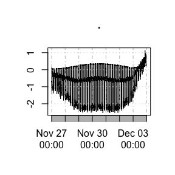

```r
faults_ls$fault2A$y %>% plot.xts()
```

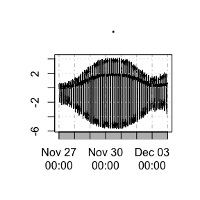

```r
faults_ls$fault2A$z %>% plot.xts()
```

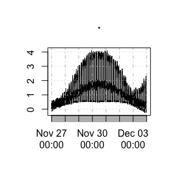

```r
faults_ls$fault2B$x %>% plot.xts()
```

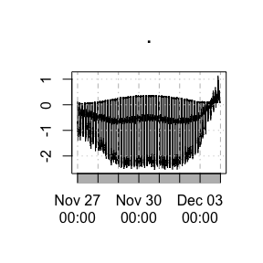

```r
faults_ls$fault2B$y %>% plot.xts()
```

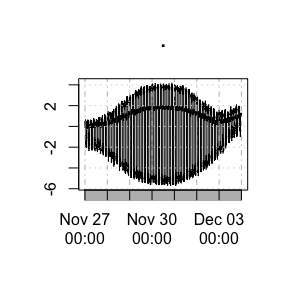

```r
faults_ls$fault2B$z %>% plot.xts()
```

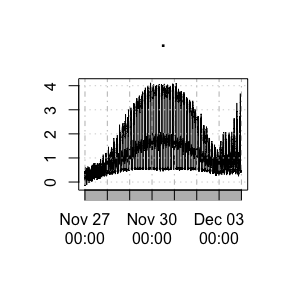

```r
faults_ls$fault3A$x %>% plot.xts()
```

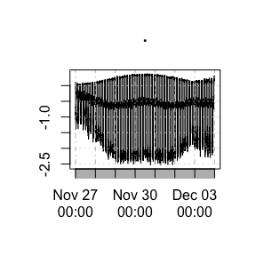

```r
faults_ls$fault3A$y %>% plot.xts()
```

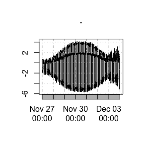

```r
faults_ls$fault3A$z %>% plot.xts()
```

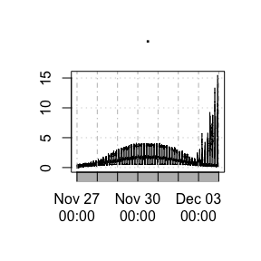

```r
faults_ls$fault3B$x %>% plot.xts()
```

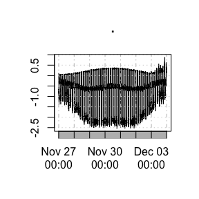

```r
faults_ls$fault3B$y %>% plot.xts()
```

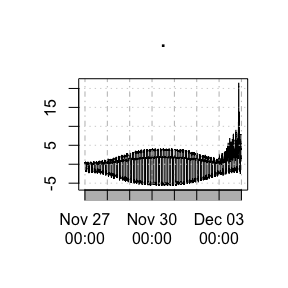

```r
faults_ls$fault3B$z %>% plot.xts()
```

## Multi-State AD-PCA Implementation

We now throw all this data we’ve just generated into our package.

```r
Sys.time()
```

```
## [1] "2017-02-02 23:58:12 CST"
```

```r
results_ls <- mvMonitoring::mspTrain(data = faults_ls$normal[,2:4],
                         labelVector = faults_ls$normal[,1],
                         trainObs = 4320,
                         updateFreq = 1440,
                         alpha = 0.001,
                         faultsToTriggerAlarm = 3,
                         lagsIncluded = 0:2)
Sys.time() # 14 seconds for 720 train, 360 update; 5 seconds for 1440, 720;
```

```
## [1] "2017-02-02 23:58:23 CST"
```

```r
# 1 second for 2880 train (two days), and 1440 update (one day).

# Alarm code: 1 = T2 alarm; 2 = SPE alarm; 3 = both
(falseAlarmRate_SPE <- sum(results_ls$FaultChecks[,5] %in% c(2,3)) /
  nrow(results_ls$FaultChecks))
```

```
## [1] 0.0006946857
```

```r
# The SPE false alarm rate hits 0 at alpha = 0.07.
(falseAlarmRate_T2 <- sum(results_ls$FaultChecks[,5] %in% c(1,3)) /
  nrow(results_ls$FaultChecks))
```

```
## [1] 0
```

```r
# The T2 false alarm rate hits 0 at alpha = 0.00015, and is at 16% at 0.07. The
# T2 statistic throws too many false alarms for my taste.
# These values were before we split the update observations by a third. These
# false alarm rates increased dramatically (0.19, 0.41), so we increased the
# number of training observations to 4320 (three days worth, up from 2880). The
# false alarm rates dropped back, but not nearly as low (0.0031, 0.0884).
```

## Test the Multi-State Monitoring function

```r
# Create six observations with lags 0:2 included
laggedTestObs <- faults_ls$normal[10073:10080, -1]
laggedTestObs <- stats::lag(laggedTestObs, 0:2)
laggedTestObs <- cbind(faults_ls$normal[10073:10080, 1], laggedTestObs)
laggedTestObs <- laggedTestObs[-(1:2),]
testDataandFlags <- mvMonitoring::mspMonitor(observations = laggedTestObs[,-1],
           labelVector = laggedTestObs[,1],
           trainingSummary = results_ls$TrainingSpecs)
testDataandFlags[6,]
```

```
##                     state         x          y           z       x.1
## 2016-12-03 23:59:00     3 0.1621549 0.03109802 -0.00831641 0.2162792
##                            y.1       z.1       x.2        y.2       z.2
## 2016-12-03 23:59:00 0.04382621 0.1883528 0.1884166 0.03576732 0.2293867
##                            SPE SPE_Flag        T2 T2_Flag Alarm
## 2016-12-03 23:59:00 0.05885875        0 0.0503335       0    NA
```

## Test the Warning function

```r
# This line will test if the function can check the last line at all.
mvMonitoring::mspWarning(testDataandFlags[1,])
```

```
##                     state         x          y          z       x.1
## 2016-12-03 23:54:00     3 0.2226361 0.05731523 0.04879455 0.2227206
##                           y.1       z.1       x.2        y.2       z.2
## 2016-12-03 23:54:00 0.0482465 0.1047281 0.2498404 0.05425972 0.1516924
##                            SPE SPE_Flag        T2 T2_Flag Alarm
## 2016-12-03 23:54:00 0.04382604        0 0.1166469       0    NA
```

```r
# These lines will test each line as if it was just received:
alarmData <- testDataandFlags
for(i in 1:nrow(testDataandFlags)){
  alarmData[1:i,] <- mvMonitoring::mspWarning(alarmData[1:i,])
}
alarmData
```

```
##                     state         x          y           z       x.1
## 2016-12-03 23:54:00     3 0.2226361 0.05731523  0.04879455 0.2227206
## 2016-12-03 23:55:00     3 0.2347690 0.03155000  0.01344216 0.2226361
## 2016-12-03 23:56:00     3 0.1827524 0.02421782  0.06196914 0.2347690
## 2016-12-03 23:57:00     3 0.1884166 0.03576732  0.22938667 0.1827524
## 2016-12-03 23:58:00     3 0.2162792 0.04382621  0.18835276 0.1884166
## 2016-12-03 23:59:00     3 0.1621549 0.03109802 -0.00831641 0.2162792
##                            y.1        z.1       x.2        y.2        z.2
## 2016-12-03 23:54:00 0.04824650 0.10472813 0.2498404 0.05425972 0.15169243
## 2016-12-03 23:55:00 0.05731523 0.04879455 0.2227206 0.04824650 0.10472813
## 2016-12-03 23:56:00 0.03155000 0.01344216 0.2226361 0.05731523 0.04879455
## 2016-12-03 23:57:00 0.02421782 0.06196914 0.2347690 0.03155000 0.01344216
## 2016-12-03 23:58:00 0.03576732 0.22938667 0.1827524 0.02421782 0.06196914
## 2016-12-03 23:59:00 0.04382621 0.18835276 0.1884166 0.03576732 0.22938667
##                            SPE SPE_Flag         T2 T2_Flag Alarm
## 2016-12-03 23:54:00 0.04382604        0 0.11664688       0    NA
## 2016-12-03 23:55:00 0.04273210        0 0.16717099       0    NA
## 2016-12-03 23:56:00 0.04895045        0 0.11944048       0     0
## 2016-12-03 23:57:00 0.05752653        0 0.08271947       0     0
## 2016-12-03 23:58:00 0.03413981        0 0.07623360       0     0
## 2016-12-03 23:59:00 0.05885875        0 0.05033350       0     0
```

# Real Data

This data was sent to use from Kate Newhart in Golden, CO.

### Import the Data files

First, we import the two data sets.

```r
library(readr)
tenDayData_v2 <- read_csv("~/Documents/GitHub/mvMonitoring/inst/tenDayData_v2.csv",
                          col_types = cols(X1 = col_datetime(format = "%Y-%m-%d %H:%M:%S")))
currentDayData_v2 <- read_csv("~/Documents/GitHub/mvMonitoring/inst/currentDayData_v2.csv",
                              col_types = cols(X1 = col_datetime(format = "%Y-%m-%d %H:%M:%S")))
```

The first data set is of a 10-day period, and the second data set is from a single day. The first columns of each data set are DateTime columns. Now we can do some basic data exploration, and save the data sets as `xts` matrices. Because `readr` imports the data frame as a tibble, we use list subsetting to get at the index column.

```r
str(tenDayData_v2, give.attr = FALSE)
```

```
## Classes 'tbl_df', 'tbl' and 'data.frame':    1437 obs. of  37 variables:
##  $ X1                                      : POSIXct, format: "2017-01-17 00:09:59" "2017-01-17 00:19:56" ...
##  $ AMBIENT_TEMP.PROCESS_VALUE              : int  57 57 57 57 57 57 57 57 57 57 ...
##  $ BIO_1.LEVEL.PROCESS_VALUE               : num  5.09 4.97 4.95 5.23 5.28 ...
##  $ BIO_1.TEMPERATURE.PROCESS_VALUE         : int  58 58 58 58 58 58 58 58 58 58 ...
##  $ BIO_1.TSS.PROCESS_VALUE                 : num  4419 4523 4428 4267 4173 ...
##  $ BIO_2.LEVEL.PROCESS_VALUE               : num  5.93 5.93 5.96 5.8 5.78 ...
##  $ BIO_2.TEMPERATURE.PROCESS_VALUE         : int  61 61 61 61 61 61 61 61 61 61 ...
##  $ BIO_2.TSS.PROCESS_VALUE                 : num  4418 4456 4489 4108 4388 ...
##  $ BIO_BLOWER_1.FLOW.PROCESS_VALUE         : num  23.95 0.1 0.1 5.35 29.34 ...
##  $ BIO_BLOWER_2.FLOW.PROCESS_VALUE         : num  0 5.22 20.94 0.02 0.01 ...
##  $ MBR.AIR_SCOUR_FLOW.PROCESS_VALUE_TANK_1 : num  5.42 5 5.71 5.2 5.36 ...
##  $ MBR.AIR_SCOUR_FLOW.PROCESS_VALUE_TANK_2 : num  5.04 5.56 4.84 5.34 5.2 ...
##  $ MBR.AIR_SCOUR_PRESSURE.PROCESS_VALUE    : num  3.72 3.71 3.72 3.75 3.72 ...
##  $ MBR.AIR_SCOUR_PRESSURE.PROCESS_VALUE_1  : num  1.88 1.72 1.96 1.82 1.85 ...
```

[output cut: 23 more lines]

```r
tenDay <- xts(tenDayData_v2[, -1], order.by = tenDayData_v2[[1]])

str(currentDayData_v2, give.attr = FALSE)
```

```
## Classes 'tbl_df', 'tbl' and 'data.frame':    75 obs. of  37 variables:
##  $ X1                                      : POSIXct, format: "2017-01-27 00:09:57" "2017-01-27 00:19:59" ...
##  $ AMBIENT_TEMP.PROCESS_VALUE              : int  51 50 50 50 50 50 50 50 50 50 ...
##  $ BIO_1.LEVEL.PROCESS_VALUE               : num  5.04 4.97 5.35 5.4 5.37 ...
##  $ BIO_1.TEMPERATURE.PROCESS_VALUE         : int  56 56 56 56 56 56 56 56 56 56 ...
##  $ BIO_1.TSS.PROCESS_VALUE                 : int  4781 4769 4841 4618 4519 4441 4705 4488 4184 4218 ...
##  $ BIO_2.LEVEL.PROCESS_VALUE               : num  5.87 5.9 5.73 5.71 5.69 ...
##  $ BIO_2.TEMPERATURE.PROCESS_VALUE         : int  59 59 59 59 59 59 59 59 59 59 ...
##  $ BIO_2.TSS.PROCESS_VALUE                 : num  5142 5130 5052 4674 4857 ...
##  $ BIO_BLOWER_1.FLOW.PROCESS_VALUE         : num  0.1 0.1 19.68 7.63 0.1 ...
##  $ BIO_BLOWER_2.FLOW.PROCESS_VALUE         : num  13.81 9.45 0 0.01 17.42 ...
##  $ MBR.AIR_SCOUR_FLOW.PROCESS_VALUE_TANK_1 : num  5.42 5.47 4.97 5.82 4.8 ...
##  $ MBR.AIR_SCOUR_FLOW.PROCESS_VALUE_TANK_2 : num  5.27 5.24 5.74 4.88 5.66 ...
##  $ MBR.AIR_SCOUR_PRESSURE.PROCESS_VALUE    : num  3.73 3.73 3.75 3.73 3.73 ...
##  $ MBR.AIR_SCOUR_PRESSURE.PROCESS_VALUE_1  : num  1.88 1.9 1.73 2.03 1.66 ...
```

[output cut: 23 more lines]

```r
oneDay <- xts(currentDayData_v2[, -1], order.by = currentDayData_v2[[1]])
```

### Clean and Save the Data

```r
oneDay <- tenDay["2017-01-26/"]
anyNA(oneDay)
```

```
## [1] FALSE
```

```r
nineDay <- tenDay["/2017-01-25"]
anyNA(nineDay)
```

```
## [1] TRUE
```

The nine day data set contains NA values, so we need to deal with these. We also must check for constant or near-constant data vectors. These vectors will cause the eigendecomposition to fail.

```r
nineDay_clean <- na.omit(nineDay)
nrow(nineDay) - nrow(nineDay_clean)
```

```
## [1] 138
```

```r
# Any constant columns? Columns with the same values can cause singularity issues.
sapply(1:ncol(nineDay_clean), function(i){
  length(unique(nineDay_clean[,i])) < 20
})
```

```
##  [1] FALSE FALSE  TRUE FALSE FALSE  TRUE FALSE FALSE FALSE FALSE FALSE
## [12] FALSE FALSE FALSE FALSE FALSE FALSE FALSE FALSE FALSE FALSE FALSE
## [23] FALSE FALSE FALSE FALSE FALSE FALSE  TRUE  TRUE FALSE FALSE FALSE
## [34] FALSE FALSE FALSE
```

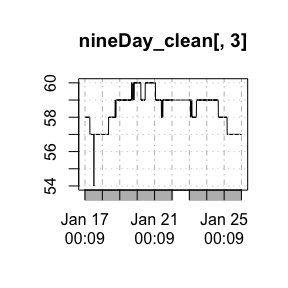

```r
# From this, we see that columns 3, 6, 29, and 30 put us at risk of singularity
# issues.
plot.xts(nineDay_clean[,3])
```

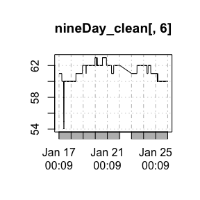

```r
plot.xts(nineDay_clean[,6])
```

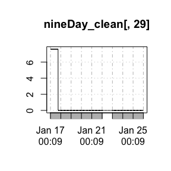

```r
plot.xts(nineDay_clean[,29])
```

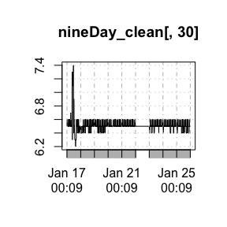

```r
plot.xts(nineDay_clean[,30])
```

```r
# We necessarily remove column 29, as it is constant for multiple entire updates
nineDay_clean <- nineDay_clean[,-29]
oneDay_clean <- oneDay[,-29]
# devtools::use_data(oneDay_clean)
# devtools::use_data(nineDay_clean)
```

The clean data frame has 138 fewer observations.

### Training the AD-PCA Model

Now to analyse the training data, and pass the training information in order to test the testing data. Because the data do not come from a process with recorded state variables (or, more specifically, that we do not have such state information), we will give a column of 1s as the labels. Futher, we have nine days’ worth of 10-minute-level observations, so we will train on $3 * 24 * 60 / 10 = 432$ observations (three days’ worth), and update each day ($24 * 60 * 10 = 144$). Further, we will lag the features by one time step.

```r
nineDayResults_ls <- mvMonitoring::mspTrain(data = nineDay_clean,
                         labelVector = rep(1, nrow(nineDay_clean)),
                         trainObs = 432,
                         updateFreq = 144,
                         alpha = 0.001,
                         faultsToTriggerAlarm = 3,
                         lagsIncluded = 0:1)
```

### Testing the New Observations

We will test the observations from the `oneDay_clean` data set. We must first lag the test observations. We’ll borrow the lags we don’t have from the previous day (in `nineDay_clean`).

```r
laggedOneDay <- stats::lag(oneDay_clean, 0:1)
laggedOneDay[1,36:70] <- nineDay_clean[nrow(nineDay_clean),]

realDataandFlags <- mvMonitoring::mspMonitor(observations = laggedOneDay,
           labelVector = rep(1, nrow(laggedOneDay)),
           trainingSummary = nineDayResults_ls$TrainingSpecs)
realDataandFlags[1,]
```

```
##                     ..1 AMBIENT_TEMP.PROCESS_VALUE
## 2017-01-26 00:09:55   1                         51
##                     BIO_1.LEVEL.PROCESS_VALUE
## 2017-01-26 00:09:55                      5.05
##                     BIO_1.TEMPERATURE.PROCESS_VALUE
## 2017-01-26 00:09:55                              57
##                     BIO_1.TSS.PROCESS_VALUE BIO_2.LEVEL.PROCESS_VALUE
## 2017-01-26 00:09:55                  4489.5                      5.91
##                     BIO_2.TEMPERATURE.PROCESS_VALUE
## 2017-01-26 00:09:55                              60
##                     BIO_2.TSS.PROCESS_VALUE
## 2017-01-26 00:09:55                    4946
##                     BIO_BLOWER_1.FLOW.PROCESS_VALUE
## 2017-01-26 00:09:55                             0.1
##                     BIO_BLOWER_2.FLOW.PROCESS_VALUE
## 2017-01-26 00:09:55                        10.50909
##                     MBR.AIR_SCOUR_FLOW.PROCESS_VALUE_TANK_1
## 2017-01-26 00:09:55                                 5.17069
##                     MBR.AIR_SCOUR_FLOW.PROCESS_VALUE_TANK_2
## 2017-01-26 00:09:55                                5.492241
##                     MBR.AIR_SCOUR_PRESSURE.PROCESS_VALUE
## 2017-01-26 00:09:55                              3.72931
##                     MBR.AIR_SCOUR_PRESSURE.PROCESS_VALUE_1
## 2017-01-26 00:09:55                               1.796552
##                     MBR.AIR_SCOUR_PRESSURE.PROCESS_VALUE_2
## 2017-01-26 00:09:55                               1.932759
##                     MBR.BATCH_VOLUME MBR_1.INF_FLOW.PROCESS_VALUE
## 2017-01-26 00:09:55         186.4841                     10.01818
##                     MBR_1.LEVEL.PROCESS_VALUE
## 2017-01-26 00:09:55                  9.844545
##                     MBR_1.PERM_FLOW.PROCESS_VALUE
## 2017-01-26 00:09:55                     0.4060345
##                     MBR_1.PERM_PRESS.PROCESS_VALUE
## 2017-01-26 00:09:55                       14.45172
##                     MBR_1.TRANS_PRESS.PROCESS_VALUE
## 2017-01-26 00:09:55                      0.01293103
##                     MBR_2.INF_FLOW.PROCESS_VALUE MBR_2.LEVEL.PROCESS_VALUE
## 2017-01-26 00:09:55                          9.1                  9.942727
##                     MBR_2.PERM_FLOW.PROCESS_VALUE
## 2017-01-26 00:09:55                     0.2862069
```

[output cut: 67 more lines]

```
## 2017-01-26 00:09:55                                3.13
##                     PERMEATE_TANK.TURBIDITY.PROCESS_VALUE.1
## 2017-01-26 00:09:55                                  0.0369
##                     RAS_TROUGH.PH.PROCESS_VALUE.1
## 2017-01-26 00:09:55                           6.5
##                     RAS_TROUGH.TEMPERATURE.PROCESS_VALUE.1
## 2017-01-26 00:09:55                                     59
##                     RAS_TROUGH.TSS.PROCESS_VALUE.1
## 2017-01-26 00:09:55                           4052
##                     SEWAGE.FLOW.PROCESS_VALUE.1 SEWAGE.FLOW.TOTAL_BATCH.1
## 2017-01-26 00:09:55                           0                  202.5519
##                     SEWAGE.LEVEL.PROCESS_VALUE.1 WAS_FLOW.PROCESS_VALUE.1
## 2017-01-26 00:09:55                        2.895                        0
##                         SPE SPE_Flag       T2 T2_Flag Alarm
## 2017-01-26 00:09:55 8423913        1 57799648       1    NA
```

For some reason, that I don’t know right now, `mspMonitor` is flagging all of these values as faults, which will trigger alarms for most of the day.

```r
# These lines will test each line as if it was just received:
realAlarmData <- realDataandFlags
for(i in 1:nrow(realDataandFlags)){
  realAlarmData[1:i,] <- mvMonitoring::mspWarning(realAlarmData[1:i,])
}
realAlarmData
```

```
##                     ..1 AMBIENT_TEMP.PROCESS_VALUE
## 2017-01-26 00:09:55   1                         51
## 2017-01-26 00:19:58   1                         51
## 2017-01-26 00:29:55   1                         51
## 2017-01-26 00:39:57   1                         51
## 2017-01-26 00:49:59   1                         51
## 2017-01-26 00:59:56   1                         51
## 2017-01-26 01:09:58   1                         51
## 2017-01-26 01:19:56   1                         51
## 2017-01-26 01:29:57   1                         51
## 2017-01-26 01:39:59   1                         51
## 2017-01-26 01:49:57   1                         50
## 2017-01-26 01:59:58   1                         50
## 2017-01-26 02:09:58   1                         50
## 2017-01-26 02:19:58   1                         50
## 2017-01-26 02:29:59   1                         50
## 2017-01-26 02:39:59   1                         50
## 2017-01-26 02:49:59   1                         50
## 2017-01-26 02:59:59   1                         50
## 2017-01-26 03:09:56   1                         50
## 2017-01-26 03:19:59   1                         50
## 2017-01-26 03:29:56   1                         49
## 2017-01-26 03:39:58   1                         49
## 2017-01-26 03:49:55   1                         49
## 2017-01-26 03:59:57   1                         49
## 2017-01-26 04:09:59   1                         49
## 2017-01-26 04:19:56   1                         49
## 2017-01-26 04:29:58   1                         49
## 2017-01-26 04:39:55   1                         48
## 2017-01-26 04:49:57   1                         49
## 2017-01-26 04:59:59   1                         49
## 2017-01-26 05:09:56   1                         48
## 2017-01-26 05:19:58   1                         48
## 2017-01-26 05:29:55   1                         48
## 2017-01-26 05:39:57   1                         48
## 2017-01-26 05:49:55   1                         48
## 2017-01-26 05:59:57   1                         48
## 2017-01-26 06:09:59   1                         48
## 2017-01-26 06:19:56   1                         48
## 2017-01-26 06:29:58   1                         48
```

[output cut: 8790 more lines]

```
## 2017-01-26 21:39:57  7291205        1 51640739       1     3
## 2017-01-26 21:49:59  7316661        1 52175826       1     3
## 2017-01-26 21:59:56  7826467        1 56100206       1     3
## 2017-01-26 22:09:59  8084864        1 58541828       1     3
## 2017-01-26 22:19:55  8061106        1 58803565       1     3
## 2017-01-26 22:29:57  8222895        1 56387549       1     3
## 2017-01-26 22:39:59  7504102        1 54499597       1     3
## 2017-01-26 22:49:56  7674588        1 54423637       1     3
## 2017-01-26 22:59:58  7939558        1 57851092       1     3
## 2017-01-26 23:09:55  8316544        1 60399806       1     3
## 2017-01-26 23:19:57  8474370        1 58456572       1     3
## 2017-01-26 23:29:59  8373055        1 56634958       1     3
## 2017-01-26 23:39:56  8365614        1 57212371       1     3
## 2017-01-26 23:49:58  8427479        1 56911350       1     3
## 2017-01-26 23:59:55  8290412        1 60010831       1     3
```

I’m not sure why this is happening. I’ll have to dig in to it later. I do notice that both the SPE and T2 statistics are off the charts. The only component affecting them equally is the projection matrix P. We are estimating a 70 ^ 2 matrix using only 432 observations at a time, so this matrix could very well be unstable (we’d need around 2500 observations to stably estimate the scatter matrix).